# Projet de programmation

## Newsletter automatisée pour les championnats de foot européens

- PAPAI Zsofia
- GOMEZ-LIMBEROPULOS Luis
- BOLMONT Adrien

## Points principaux

1. Web Scraping sur un site de résultats sportifs  
2. Opérations de filtrage sur les données collectées  
3. Mailing automatisé

## 1. Web Scraping sur un site de résultats sportifs

Nous opterons pour l’utilisation du package Selenium afin d’effectuer le scrapping.

```python
from selenium import webdriver
from selenium.webdriver.chrome.service import Service
from selenium.webdriver.chrome.options import Options

# Spécifiez le chemin d'accès au pilote du navigateur et le user
DRIVER_PATH = "C:/Users/Admin/Downloads/chromedriver-win64/chromedriver.exe"
user_agent = "Mozilla/5.0 (Windows NT 10.0; Win64; x64) AppleWebKit/537.36 (KHTML, like Gecko) Chrome/58.0.3029.110 Safari/537.36"

# Créer un objet Options
options = Options()
options.binary_location = "C:/Program Files/Google/Chrome/Application/chrome.exe"
options.add_argument(f'user-agent={user_agent}')
options.headless = True  # Pour exécuter Chrome en mode headless (sans interface graphique), décommentez cette ligne
```

### a. Extraire les rankings des 5 ligues

```python
def rankings():
    Rankings_leagues = {}
    for league in Leagues_list:
        # Open the link
        driver = webdriver.Chrome(service=Service(DRIVER_PATH), options=options)
        driver.get(OF_lien + league[0] + "/table")

        time.sleep(5)

        try:
            click_button = driver.find_element(By.ID, "onetrust-accept-btn-handler")
            click_button.click()
        except:
            pass  # If the button is not found or there's an error, ignore

        # Find the table element
        Ranking = driver.find_element(By.XPATH, "//*[@id='__next']/main/div/div/div[6]")
        table_text = Ranking.text

        Rankings_leagues[league[1]] = [table_text]


        String = Rankings_leagues[league[1]][0]
        values_String = String.split('\n')
        del values_String[:6]

        data_String = [values_String[i:i+8] for i in range(0, len(values_String), 8)]
        df_String = pd.DataFrame(data_String, columns=["Position", "Team", "Games", "Wins", "Draws", "Losses", "Goals", "Points"])
        Rankings_leagues[league[1]] = df_String

    driver.quit()
    return Rankings_leagues
```

### b. Extraire les matchs d’une journée

```python
def matchs(lien):
    Matchs = {}

    driver = webdriver.Chrome(service=Service(DRIVER_PATH), options=options)
    driver.get(lien)

    time.sleep(5)

    try:
        click_button = driver.find_element(By.ID, "onetrust-accept-btn-handler")
        click_button.click()
    except:
        pass

    for i in range(5, 12):
        xpath = "//*[@id='__next']/main/div/div/div[{0}]/div".format(i)
        matchs = driver.find_element(By.XPATH, xpath)
        Str = matchs.text
        values_Str = Str.split('\n')

        for league in Leagues_list:
            if values_Str[0] in league[1]:

                del values_Str[:3]
                del values_Str[-1]

                data_Str = [values_Str[i:i+4] for i in range(0, len(values_Str), 4)]
                df_Str = pd.DataFrame(data_Str, columns=["Home Team", "Away Team", "Date", "Time"])
                df_Str["League"] = league[1]

                Matchs[league[1]] = df_Str

    driver.quit()
    return Matchs
```

## 2. Opérations de filtrage sur les données collectées

Qu’est ce qui rend un match intéressant ?

- Derby / Classiques
- 1ere place du championnat en jeu
- qualifications en championnats européens
- maintien en ligue
- matchs européens
- matchs de votre équipe favorite

## a. Filtrer les données

- on utilise des fonction qui renvoie des booléens pour savoir si un match est intéressant ou pas
- s’il vérifie la condition, elle renvoie True sinon False

```python
def position(matchs_dict, ranking, dict_league):
    for league, matches_df in matchs_dict.items():

        table = ranking.get(league)

        CL = dict_league.get(league)[0]
        EU = dict_league.get(league)[1]
        REG = dict_league.get(league)[2]

        matches_df['Championship'] = False
        matches_df['UEFA CL'] = False
        matches_df['UEFA EL'] = False
        matches_df['Relegation'] = False

        for index, match in matches_df.iterrows():
            Place_HT = table.index[table['Team'] == match['Home Team']].tolist()
            Place_HT = int(Place_HT[0])
            Place_AT = table.index[table['Team'] == match['Away Team']].tolist()
            Place_AT = int(Place_AT[0])

            for team in [Place_HT, Place_AT]:
                if team != 0 and abs(int(table['Points'][team]) - int(table['Points'][0])) < 4:
                    matches_df.at[index, 'Championship'] = True
                elif team == 0 and abs(int(table['Points'][1]) - int(table['Points'][0])) < 4:
                    matches_df.at[index, 'Championship'] = True

            for i in CL:
                if team != i and abs(int(table['Points'][team]) - int(table['Points'][i])) < 4:
                    matches_df.at[index, 'UEFA CL'] = True

            for i in EU:
                if team != i and abs(int(table['Points'][team]) - int(table['Points'][i])) < 4:
                    matches_df.at[index, 'UEFA EL'] = True

            for i in REG:
                if team != i and abs(int(table['Points'][team]) - int(table['Points'][i])) < 4:
                    matches_df.at[index, 'Relegation'] = True
```

## b. Constitution des blocs de texts

- Formater le texte selon les types de matchs en insérants les informations extraites des data frames

```python
import numpy as np

synonymes_match = ["match", "choc", "derby", "bataille", "rencontre"]
synonymes_mythique = ["mythique", "légendaire", "au sommet", "célèbre", "historique"]

def classic(ligue):
    n = np.random.randint(1,5)
    for index, row in matches.iterrows():
        if row["Classic"]:
            message = f"Alerte derby!\n{row['Home Team']} affronte {row['Away Team']} dans un {synonymes_match[n]} {synonymes_mythique[n]} de la {row['League']} le {row['Date']} à {row['Time']}."
            return print(message)

    return None
```

## ordre de priorité des conditions :

```python
def autres_match(ligue):
    messages = ""
    for index, row in matches.iterrows():
        mess_champion = ""
        mess_CL = ""

        if row['Championship']:
            mess_champion = f"\n\nMatch pour la première place : \n{row['Home Team']} vs {row['Away Team']} le {row['Date']} à {row['Time']}. \n"
            messages += mess_champion
            continue

        if row['UEFA CL']:
            mess_CL = f"\n\nPlace en Champions League en jeu : \n{row['Home Team']} vs {row['Away Team']} le {row['Date']} à {row['Time']}. \n"
            messages += mess_CL
            continue

    return print(messages)
```

## 3. Mailing automatisé

A la suite du scrapping et du filtrage, il faut procéder à l’envoi des mails. Cette phase est découpée dans le code en 3 principales parties :

- Fonction sujet_mail
- Fonction envoyer_email
- Fonction corps_mail

```python
#library(reticulate)
#use_python("C:/Users/adrie/myenv/Scripts/python.exe")
import datetime
import smtplib
import pandas as pd
from email.mime.text import MIMEText
from email.mime.multipart import MIMEMultipart
from datetime import datetime

# Données expéditeurs
destinataire_email = "adrien.bolmont@etu.unistra.fr"

# Données des utilisateurs
donnees_utilisateurs = {
    'name': ['Dupont', 'Durand', 'Tremblay'],
    'fname': ['Jean', 'Marie', 'Pierre'],
    'mail': ['adrien.bolmont@etu.unistra.fr', 'adrienbolmontempsai@gmail.com', 'adrienbolmont@gmail.com'],
    'Club': ['Real Madrid', 'Liverpool', 'FC Barcelona']
}

data_match = {
    'team_1': ['Real Madrid', 'Paris','Lyon'],
    'team_2': ['Sochaux', 'Liverpool','Strasbourg']
    }


# Création du DataFrame de data user et matchs
df_user_data = pd.DataFrame(donnees_utilisateurs)
df_match_data = pd.DataFrame(data_match)

print("df_user_data :\n\n", df_user_data.head().to_string(index=False))
#print("\ndf_match_data :\n\n", df_match_data.head().to_string(index=False))
```

## a. Fonction sujet_mail

Objectifs : personnaliser et automatiser l’objet du mail

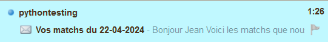

```python
# Construction de l'objet du mail avec la date du jour
def sujet_mail(phrase_fixe, date):
    date_string = datetime.date(annee, mois, jour)
    return phrase_fixe + " " + date_string
```

## b. Fonction envoyer_mail

- création de la procédure d’envoi du mail

```python
def envoyer_email(destinataire_email, corps_mail, date):
    message = MIMEMultipart()
    expediteur_email = "pythontesting@laposte.net"
    message['From'] = expediteur_email
    message['To'] = destinataire_email
    message['Subject'] = sujet_mail(" Vos matchs du", date)
    message.attach(MIMEText(corps_mail, 'plain'))

    # Établir une connexion avec le serveur SMTP de Laposte
    serveur_smtp = smtplib.SMTP('smtp.laposte.net', 587)
    serveur_smtp.starttls()

    # Se connecter au compte expéditeur
    serveur_smtp.login(expediteur_email, "Nouveaumotdep@sse2024")

    # Envoyer l'e-mail
    serveur_smtp.send_message(message)

    # Fermer la connexion
    serveur_smtp.quit()
```

## c. Fonction corps_mail

- fonction finale pour l’envoi personnalisé automatisé d’un mail à un utilisateur du service

```python
def corps_mail(User, matchs_dict, date):

    for index, row in User.iterrows():

        Message0 = f"Bonjour {row['fname']} \n\nVoici les matchs que nous vous conseillons le {date} :\n"
        Message1 = fav_team(row['Club'], matchs_dict)
        Message2 = classic(matchs_dict)
        Message3 = autres_match(matchs_dict)
        Message4 = "\n\nSalutations footbalistiques."

        Message_f = Message0 + Message1 + Message2 + Message3 + Message4

        envoyer_email(row['mail'], Message_f, date)
```

## 4. Conclusion

Limites :

- données utilisateurs dans notre code sont fixes
- lancement du code n’est pas automatique